# 20201012-p8122_hw2_jsg2145

Jared Garfinkel

10/12/2020

## Read in data

```r
data = read_csv("./data/light.csv") %>%
  janitor::clean_names()

data
```

[output not shown]

# Problem 1

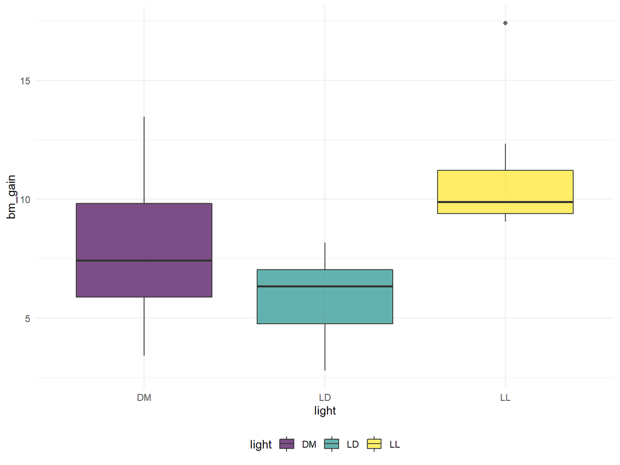

```r
data %>%
  ggplot(aes(x = light, y = bm_gain, fill = light)) +
  geom_boxplot(alpha = 0.7)
```

# Problem 2

Assuming DM = darkness, LD = dim, and LL = bright

### subset the data

```r
df = data %>%
  filter(light %in% c("DM", "LL"))
```

# Problem 3

Recode the variables and rename them for ease of use.

```r
df = df %>%
  mutate(light = recode(light,
                        "DM" = "0",
                        "LL" = "1")) %>%
  rename("tr" = light,
         "y" = bm_gain)
```

We will need the estimand and the sampling variance to evaluate the causal effects of light at night on weight gain in mice for Neyman’s approach, or the observed outcomes, the treatment group assignments, and the covariates, for Fisher’s approach.

# Problem 4

$T_{obs} = \frac{\sum_{i=1}^{n}{A_iY_{1i}}}{N_1} - \frac{\sum_{i=1}^{n}(1-A_i)Y_{0i}}{N_0}$

```r
t_obs = df %>%
  summarize(t_obs = sum(y*(tr==1)/sum(tr==1) - y*(tr==0)/sum(tr==0)))
```

T_obs is 3.151.

# Problem 5

```r
amat = perm::chooseMatrix(19, 10)

nrow(amat)
```

```
## [1] 92378
```

There are 92378 different ways to arrange the A matrix.

# Problem 6

The sharp null hypothesis of no difference is that for each observation there is no treatment effect.

That is: $H_0: \tau_i = Y_{0i} - Y_{1i} = 0$

```r
atilde = amat[1,]

t_stat = df %>%
  bind_cols(atilde) %>%
  rename("atilde" = "...10") %>%
  summarize(t_stat = sum(y*(atilde==1)/sum(atilde==1)) - sum(y*(atilde==0)/sum(atilde==0)))
```

The t-statistic under the sharp null hypothesis is 2.1415556

# Problem 7

Make the dataframe.

```r
rdist = vector(mode = "list", length = nrow(amat))
atilde = NULL
for (i in 1:nrow(amat)) {
  atilde[[i]] = amat[i,] %>%
    tibble()
  rdist[[i]] = df %>%
    bind_cols(atilde[i]) %>%
    rename("atilde" = ".") %>%
    summarize(rdist = sum(y*(atilde==1)/sum(atilde==1)) - sum(y*(atilde==0)/sum(atilde==0)))
}

rdist = bind_rows(rdist)
```

# Problem 8

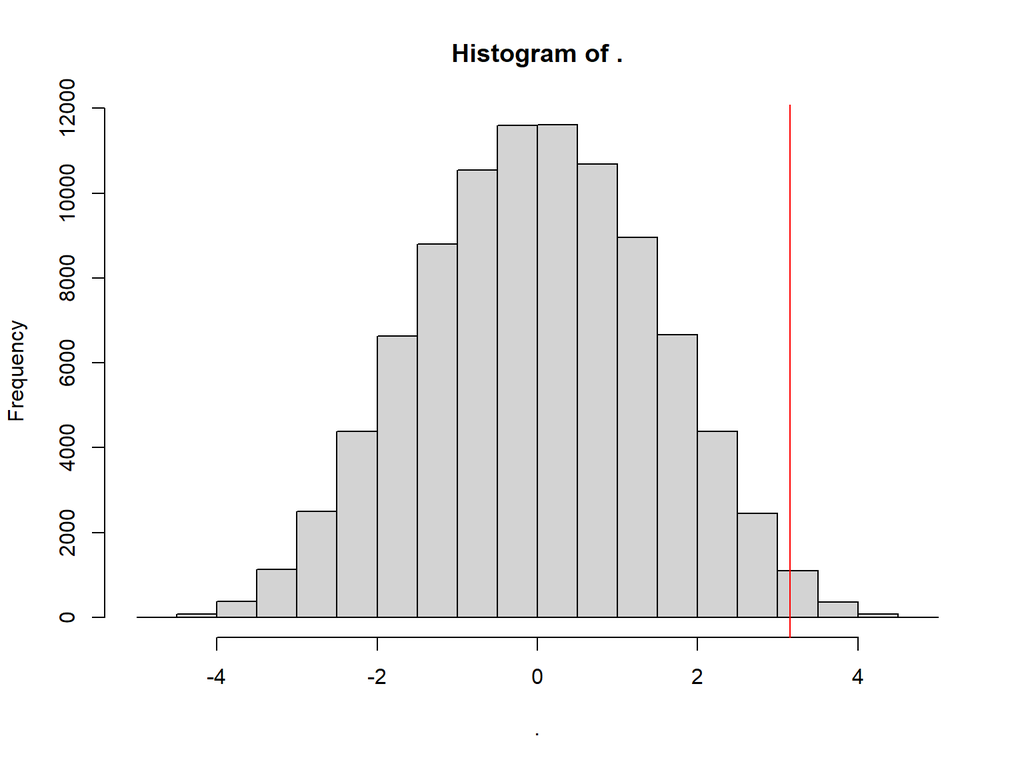

```r
rdist %>%
  pull(rdist) %>%
  hist()
abline(v = pull(t_obs, t_obs), col="red")
```

# Problem 9

```r
p <- mean(rdist >= pull(t_obs, t_obs))
p
```

```
## [1] 0.01183182
```

# Problem 10

The p-value is less than 0.05, so we conclude there is evidence to suggest that bright lights cause an increase the amount of weight gain in subjects over the study period in one or more subjects.